# root_stem_crown_comparison

Expected output: Table, columns: PCAs, metadata Category, pvals

```r
lmMetadata = function(testingData, label){

  index = c()
  metaName = c()
  metaPval = c()
  indexName = c()
  r_sqrd = c()

  for (i1 in 1:nrow(testingData)){
    for (i2 in 1:nrow(metadata)){
      tryCatch(
       {
        myLm = lm( unlist(testingData[i1,]) ~ as.factor(as.character(metadata[i2,])))
        index = c(index, i1)
        metaName = c(metaName, row.names(metadata)[i2])
        indexName = c(indexName, row.names(testingData)[i1])
        metaPval =  c(metaPval, anova(myLm)$"Pr(>F)"[1])
        r_sqrd =  c(r_sqrd, summary(myLm)$r.squared)
        },
        error=function(cond) {
          print('an error is thrown')
          message(cond)
        },
        warning=function(cond) {
          print('a warning is thrown')
          message(cond)
          # Choose a return value in case of warning
          #return(NULL)
        }
      )
    }
  }

  pdf(paste(ds, "HistogramRsqrdMetadata", label, "Lm.pdf", sep=""))
  hist(r_sqrd,
    main = paste(ds, ' Histogram of lm r squared ', label),
    xlab = 'Adjusted R squared',
    breaks = 50
  )
  dev.off()

  pdf(paste(ds, "HistogramPvalMetaVs", label, "Lm.pdf", sep=""))
  hist(metaPval,
    main = paste(ds, ' Histogram of lm pvalues for ', label),
    xlab = 'Uncorrected pvalues',
    breaks = 50
  )
  dev.off()

  metaPvalAdj = p.adjust(metaPval, method = "BH")
  dFrame <- data.frame(metaPvalAdj,metaName,index, indexName)
  dFrame <- dFrame [order(dFrame$metaPvalAdj),]

  write.table(dFrame, file=paste(ds, "MetaVs",label,"LinearMod.txt", sep = ''), row.names=FALSE, sep="\t")

  write.table(format(dFrame, digits = 3), file=paste(ds, "MetaVs",label,"ShortLinearMod.txt", sep = ''), row.names=FALSE, sep="\t")

  pubDf = reshape(dFrame, idvar = 'indexName', timevar = 'metaName', direction="wide", sep="", drop = "index")
  write.table(format(pubDf, digits = 3), file=paste(ds, "MetaVs",label,"ReformatShortLinearMod.txt", sep = ''), row.names=FALSE, sep="\t")

  #print(pubDf)

  pdf(paste(ds,"MetaVs",label,"LinearMod.pdf", sep = ""))


  for( i in 1:nrow(dFrame)){
    aTitle <- paste(label, ': ', dFrame$indexName[i], " vs ",  dFrame$metaName[i], "\nAdj Pval: ", formatC(dFrame$metaPvalAdj[i]), sep = '')

    par(bty = 'l',
    mar = c(5, 4, 5, 2) + 0.1,
    # cex = 1.3,
    # cex.lab = 1.5,
    cex.axis = 1.45)
    plot( as.factor(as.character(metadata[as.character(dFrame$metaName[i]),])),
      unlist(testingData[dFrame$index[i],]),
      main = aTitle,
      xlab = as.character(dFrame$metaName[i]),
      ylab = paste(as.character(dFrame$indexName[i])),
      col = brewer.pal(length(metadata[as.character(dFrame$metaName[i]),]),"Accent")
      )
  }
  dev.off()

  print('lmMetadata complete')
}#end of lmMetadata
bioActiveArr= c('Kavain', 'Dihydromethysticin', 'Desmethoxyyangonin')
mainBioActive = metabolites[bioActiveArr,]
lmMetadata(mainBioActive, 'BioActiveMetabolitesOnly')
```

```
[1] "lmMetadata complete"
```

Compare each metabolite to each metadata. Expected output: Table1: Columns: anova adjusted pval (sorted), metadata name, metabolite name Table2: Names and rows of metadata and metabolites for failed attempts, Table3: Posthoc pvalues for ‘plant part’ Table4 and Table5: <- this turned out too hard for the model Post hoc pvalues for ‘tissue’ and ‘plant part’ Table5 Columns: Metabolite | lateral_root - crown_root | stem - crown_root | stem - lateral_root Box plots for each metabolite and each metadata

```r
lmeMetadata = function(testingData, label){
  if(!require(nlme)){install.packages("nlme")}
  library("nlme")

  metaboliteNames = c()
  metadataCatagories = c()
  pvals = c()

  #vessel to hold the failures for future reference
  failedLme <<- data.frame(#'<<-' gives global scope
    metaboliteName = character(0),
    metaboliteRowNum = numeric(0),
    metadataName = character(0),
    metadataRowNum = numeric(0)
    )

  for (i1 in 1:nrow(testingData)){
    #print(paste('i1:',i1))
    for (i2 in 1:nrow(metadata)){
      #print(paste('i2:',i2))
      if (row.names(metadata)[i2] != 'plant number'){
        tryCatch(
          {
          metabo = unlist(testingData[i1,])
          metad = as.factor(unlist(metadata[i2,]))
          pn = unlist(metadata['plant number',])
          myD = data.frame(metabo, metad, pn)
          myLme = lme(metabo ~ metad,
            method= "REML",
            random = ~1 | pn,
            na.action = 'na.omit',
            data = myD
            )
          myAnova = anova(myLme)
          myPval = myAnova$"p-value"[2]
          metaboliteNames = c(metaboliteNames, row.names(testingData)[i1])
          metadataCatagories = c(metadataCatagories, row.names(metadata)[i2])
          pvals =  c(pvals, myPval)
          },
          error=function(cond) {
            #metaboliteName, metaboliteRowNum, metadataName, metadataRowNum
            myRow = list(row.names(testingData)[i1], i1, row.names(metadata)[i2], i2)
            names(myRow) = c('metaboliteName', 'metaboliteRowNum', 'metadataName', 'metadataRowNum')
           # print(metabo)
            failedLme <<- rbind(failedLme, data.frame(myRow))
            #print('an error is thrown')
            message(cond)
            # Choose a return value in case of error
            # return(NA)
          },
          warning=function(cond) {
            print('a warning is thrown')
            myRow = list(row.names(testingData)[i1], i1, row.names(metadata)[i2], i2)
            names(myRow) = c('metaboliteName', 'metaboliteRowNum', 'metadataName', 'metadataRowNum')
            #print(names(myRow))
            failedLme = rbind(failedLme, data.frame(myRow))
            #print('failedLme warning')
            message(cond)
            # Choose a return value in case of warning
            #return(NULL)
          }
        )
      }
    }
  }

  pvalAdj = p.adjust(pvals, method = "BH")

  dFrame <- data.frame(pvals,pvalAdj,metaboliteNames,metadataCatagories)
  dFrame <- dFrame[order(dFrame$pvalAdj),]

  write.table(dFrame, file=paste(ds, "MetaVs", label, "Lme.txt", sep = ''), row.names=FALSE, sep="\t")

  write.table(failedLme, file=paste(ds, "FailedMetaVs", label, "Lme.txt", sep = ''), row.names=FALSE, sep="\t")

  pubDf = reshape(dFrame, idvar = 'metaboliteNames', timevar = 'metadataCatagories', direction="wide", sep="", drop = 'pvals')
  write.table(format(pubDf, digits = 3), file=paste(ds, "MetaVs",label,"ReformatShortLme.txt", sep = ''), row.names=FALSE, sep="\t")

  pdf(paste(ds, "HistogramMetaVs", label, ".pdf", sep=""))
  hist(pvals,
    main = paste('Histogram of lme pvalues for ', label),
    xlab = 'Uncorrected pvalues',
    breaks = 50
  )
  dev.off()

  pdf(paste(ds, "MetaVs", label, "Lme.pdf", sep=""))
  par(bty = 'l',
    mar = c(5, 4, 5, 2) + 0.1)
  for( i in 1:nrow(dFrame)){
    aTitle <- paste(  dFrame$metaboliteNames[i], "vs",  dFrame$metadataCatagories[i], "\nAdjusted Pvalue=", dFrame$pvalAdj[i])

    plot( as.factor(as.character(metadata[as.character(dFrame$metadataCatagories[i]),])),
      unlist(testingData[as.character(dFrame$metaboliteNames[i]),]),
      main = aTitle,
      xlab = as.character(dFrame$metadataCatagories[i]),
      ylab = as.character(dFrame$metaboliteNames[i]),
      # col = as.factor(as.character(metadata[as.character(dFrame$metadataCatagories[i]),]))
      )
  }
  dev.off()
  print('successfull run of lmeMetadata')
}#end function
```

```r
lmeMetadata(metabolites, 'Metabolites')
```

```
contrasts can be applied only to factors with 2 or more levelscontrasts can be applied only to factors with 2 or more levelscontrasts can be applied only to factors with 2 or more levels
```

```
[1] "successfull run of lmeMetadata"
```

```r
lmeMetadata(t(myPCA), 'PCA')
```

```
[1] "successfull run of lmeMetadata"
```

```r
myPcaT = data.frame(t(myPCA))
lmMetadata(myPcaT, 'Pca')
```

```
[1] "lmMetadata complete"
```

```r
lmMetadata(myPcaT[c(1,2,3),], "PcaTop3")
```

```
[1] "lmMetadata complete"
```

```r
lmeMetadata(myPcaT[c(1,2,3),], "PcaTop3")
```

```
[1] "successfull run of lmeMetadata"
```

```r
lmMetadata(metabolites, 'Metabolites')
```

```
[1] "an error is thrown"
```

```
contrasts can be applied only to factors with 2 or more levels
```

```
[1] "an error is thrown"
```

```
contrasts can be applied only to factors with 2 or more levels
```

```
[1] "an error is thrown"
```

```
contrasts can be applied only to factors with 2 or more levels
```

```
[1] "lmMetadata complete"
```

Pairwise tests (code from Dr. Fodor https://github.com/afodor/metagenomicsTools/blob/master/src/scripts/aaronMetabolites/quickPairwise.txt)

```r
expGroups = unique(unlist(metadata['tissue',]))
numGroups = length(expGroups)
iGroups <- vector()
jGroup <- vector()
index <- 1
pValues <- vector()
metabloliteName <- vector()
for( m in 1:nrow(metabolites) )
{
    for ( i in 1:(numGroups-1) )
    {
        iData <- metabolites[m, which(metadata['tissue', ] == expGroups[i])]

        for( j in i:numGroups)
        {
            jData <- metabolites[m,which(metadata['tissue', ] == expGroups[j])]
            if( sum(!is.na(iData)) >1 & sum(!is.na(jData)) >1   )
            {
                iGroups[index]  <- expGroups[i]
                jGroup[index] <-expGroups[j]
                pValues[index] <- t.test(iData, jData)$p.value
                metabloliteName[index] <- row.names(metabolites)[m]
                index = index + 1
                #print( paste(index, " " , metabloliteName, "\n"))
            }
        }
    }
}
myFrame <-data.frame(metabloliteName,iGroups,jGroup, pValues)
myFrame$pvalAdj = p.adjust(pValues, method="BH")
myFrame = myFrame[order(myFrame$pvalAdj),]
write.table(myFrame, file=paste(ds, 'PairwiseTtest.txt', sep = ''), row.names=FALSE, sep="\t")
sum(p.adjust(pValues, method="BH") < .1)
```

```
[1] 273
```

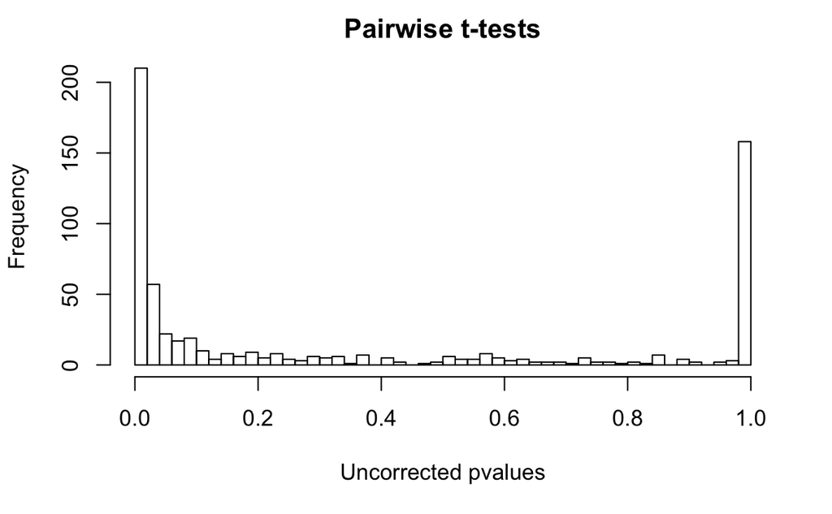

```r
hist(pValues,
  breaks = 50,
  xlab = 'Uncorrected pvalues',
  main = 'Pairwise t-tests'
  )
```

For publication purposes, I need to get just the metabolites of interest: Kavain Dihydromethysticin Desmethoxyyangonin

```r
#there will be two Dihydromethysticin in lc neg data
bioActiveArr= c('Kavain', 'Dihydromethysticin', 'Desmethoxyyangonin')
mainBioActive = metabolites[bioActiveArr,]
lmeMetadata(mainBioActive, 'BioActiveMetabolitesOnly')
```

```
[1] "successfull run of lmeMetadata"
```

```r
lmMetadata(mainBioActive, 'BioActiveMetabolitesOnly')
```

```
[1] "lmMetadata complete"
```

```r
lmMetadata(mainBioActive, 'BioActive')
```

```
[1] "lmMetadata complete"
```

```r
expGroups = unique(unlist(metadata['tissue',]))
numGroups = length(expGroups)
iGroups <- vector()
jGroup <- vector()
index <- 1
pValues <- vector()
metabloliteName <- vector()
for( m in 1:nrow(mainBioActive) )
{
    for ( i in 1:(numGroups-1) )
    {
        iData <- mainBioActive[m, which(metadata['tissue', ] == expGroups[i])]

        for( j in i:numGroups)
        {
            jData <- mainBioActive[m,which(metadata['tissue', ] == expGroups[j])]
            if( sum(!is.na(iData)) >1 & sum(!is.na(jData)) >1   )
            {
                iGroups[index]  <- expGroups[i]
                jGroup[index] <-expGroups[j]
                pValues[index] <- t.test(iData, jData)$p.value
                metabloliteName[index] <- row.names(mainBioActive)[m]
                index = index + 1
                #print( paste(index, " " , metabloliteName, "\n"))
            }
        }
    }
}
myFrame <-data.frame(metabloliteName,iGroups,jGroup, pValues)
myFrame$pvalAdj = p.adjust(pValues, method="BH")
myFrame = myFrame[order(myFrame$pvalAdj),]
write.table(myFrame, file=paste(ds, 'MainBioactive', 'PairwiseTtest.txt', sep = ''), row.names=FALSE, sep="\t")
sum(p.adjust(pValues, method="BH") < .1)
```

```
[1] 44
```

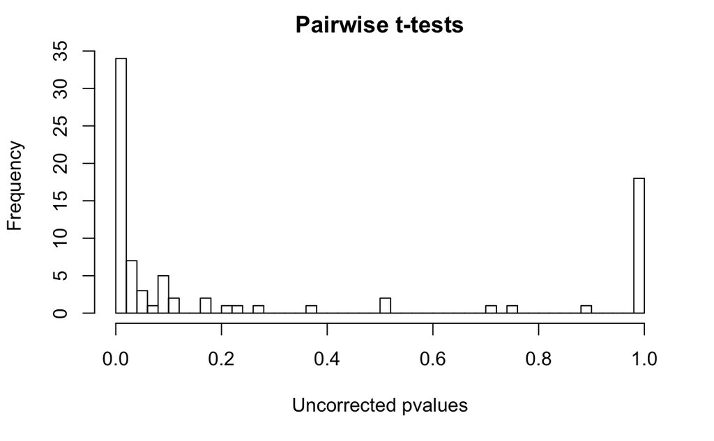

```r
hist(pValues,
  breaks = 50,
  xlab = 'Uncorrected pvalues',
  main = 'Pairwise t-tests'
  )
```